# Comportamiento del consumo de oxígeno y disponibilidad de camas en los hospitales del Perú entre los meses de marzo y septiembre del 2021

## Introducción

Entre el año 2020 y 2021, en el Perú se dieron los picos más altos de contagio de Covid 19 debido a la pandemia que se vive hasta la actualidad. Esto dejó consecuencias en los sectores más importantes, pero el que se vio más afectado fue el de salud con el rápido incremento de contagios, personas en cuidados intensivos y pérdidas demográficas. Debido a ello la demanda de oxígeno se incrementó, pues se usa con los pacientes que entran a Unidad de Cuidados Intensivos (UCI).Con este estudio se busca hacer un análisis de cómo fue la disponibilidad de este recurso en el país en el año 2021, analizar la existencia de deficiencias que hubieron, y comparar su disponibilidad entre diferentes localidades del Perú.

- **¿Es el estudio de interés para la audiencia?**

Sí, el estudio resulta útil en el ámbito sanitario debido a que se puede dar a conocer la variación de la demanda, uso y disponibilidad de este implemento necesario para el tratamiento contra el Covid 19 y otras enfermedades. Además de lo atravesado durante los últimos 2 años durante la pandemia, el poder conocer el nivel en que se encuentra nuestro sistema de salud es un tema de interés para la audiencia, que en esta ocasión sería el pueblo peruano.

- **¿Qué información se desea aportar al final del estudio?**

Al final del estudio se espera aportar información sobre qué tan bien preparada y qué tan efectiva fue la respuesta del sistema de salud ante la llegada del COVID 19.

- **Factibilidad de la investigación:**

La investigación es factible pues se obtuvo información de la Superintendencia Nacional de Salud

- Información por días del consumo y disponibilidad de Oxígeno de los establecimientos de salud públicas, privadas y mixtas a nivel nacional; registrado en el Reporte de Disponibilidad de Oxígeno Medicinal | DU 012-2021 y DS 010-2021-SA
- Reporte de camas UCI y Hospitalización en zona COVID y No COVID Data histórica del Formato F500.2 - Registro de Disponibilidad de Camas de Hospitalización y UCI en zona COVID y No COVID, a nivel nacional y de todos los subsistemas.
- **Marco Teórico (Niveles y categorías)**
- Nivel 1 de atención:
  - Categoría I-1. Puesto de salud, posta de salud o consultorio con profesionales de salud no médicos.
  - Categoría I-2. Puesto de salud o posta de salud (con médico). Además de los consultorios médicos (con médicos con o sin especialidad).
  - Categoría I-3. Corresponde a los centros de salud, centros médicos, centros médicos especializados y policlínicos.
  - Categoría I-4. Agrupan los centros de salud y los centros médicos con camas de internamiento.
- Nivel 2 de atención:
  - Categoría II-1. El conjunto de hospitales y clínicas de atención general.
  - Categoría II-2. Corresponde a los hospitales y clínicas con mayor especialización.
  - Categoría II-E. Agrupan a los hospitales y clínicas dedicados a la atención especializada.
- Nivel 3 de atención:
  - Categoría III-1. Agrupan los hospitales y clínicas de atención general con mayores unidades productoras de servicios de salud.
  - Categoría III-E. Agrupan los hospitales y clínicas de atención general con mayores unidades productoras de servicios de salud y servicios en general.
  - Categoría III-2. Corresponden a los institutos especializados.

    ```
                                                          (ESAN, 2018)
    ```

- **Planificación**

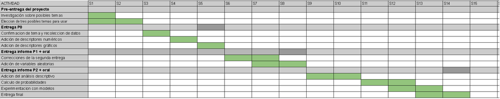

Imagen

## Datos

- **Librerias**

Cargamos las librerías para leer nuestros archivos csv y ejecutar algunos comandos en especifico

```r
library(readr)
library(vctrs)
library(dplyr)
library(modeest)
library(RColorBrewer)
```

### **Recolección de datos:**

Para recolectar la información se hizo un registro de ciertas instituciones de salud durante la pandemia en el año 2021 mediante el método de muestra aleatoria estratificada. Los datos recolectados fueron con respecto a la cantidad de tanques de oxígeno y cantidad de camas con los requisitos necesarios para atender a los pacientes con covid-19 (con ventiladores mecánicos). Para ello se crearon 2 bases de datos (Oxigeno.csv y Camas.csv) que se mostrarán más adelante.

Para realizar este registro se contó con la ayuda del personal de cada Institución que formó parte de la muestra, tomando datos de la Institución a la cual cada uno pertenece para luego juntar todo en una sola base de datos. Se hizo de esta manera debido a la gran cantidad de instituciones que existen y la gran distancia que existe entre ellas, por lo que no se podría haber recolectado información visitando a cada una de ellas. La base de datos generada será el pilar que permitirá llevar a cabo el trabajo de análisis de datos que se realizará durante el presente proyecto.

**Población Objetivo:** Instituciones de servicio de salud públicas y privadas nacionales.

**Muestra:** 506 Instituciones de servicio de salud públicas y privadas nacionales.

**Tipo de Muestreo:** El tipo de muestreo elegido para la obtención de nuestra muestra, fue el muestreo aleatorio estratificado. Los estratos fueron las instituciones de servicio de salud públicas y privadas de cada región del país. Se les aplicó el muestreo simple para cada uno respectivamente. Para finalmente obtener nuestra muestra de 506 instituciones públicas y privadas nacionales.

**Sesgo:** Nuestros datos provienen de una base de datos, por lo que tenemos que considerar algunos sesgos presentes:

- Sesgo de extraer registros: Nosotros no recolectamos los datos, por lo que no podemos evidenciar ni garantizar que todos hayan sido registrados de manera correcta.

### **Base de datos Oxígeno**

Cargamos nuestras bases de datos de OXIGENO.csv

```r
oxigenoS<-read_csv("OXIGENO.CSV")
```

- ** Limpieza de Datos ** Ahora se procede a realizar la limpieza de datos para excluir las variables que no requerimos para el estudio. Luego especificamos el tipo de variable a la cual corresponde cada una. Estos nuevos datos se insertan en la variable ‘oxigenoS1’.

Ahora se buscará si existen datos duplicados con la función unique()

```
## [1] "Cantidad de observaciones duplicadas: 25493"
```

Como se puede ver, hay una gran cantidad de observaciones duplicadas,es decir hubo una deficiencia evidente en cuánto a la recolección de los datos, por los que que se omitirán a estas y se trabajará con una nueva base filtrada bajo este parámetro:

```r
OxigenoD <- unique(oxigenoS1)
```

Inspeccionamos la cantidad de datos faltantes y observaciones incompletas dentro de nuestra nueva base de datos.

```
## [1] "Cantidad de datos faltantes:  11356"
```

```
## [1] "Cantidad de observaciones incompletas:  1617"
```

Ahora calcularemos el porcentaje que representan nuestros datos incompletos en toda la base de datos.

```
## [1] "Porcentaje de datos incompletos (%) :  1.24"
```

Calculamos la cantidad de datos faltantes por variable para saber si hay variables con mayor cantidad de datos o si están distribuidas de manera equitativa en todas.

```
##            FECHAREGISTRO                   NOMBRE                    NIVEL
##                        0                       11                       11
##                    GRUPO                   REGION        CIL_TOT_CILINDROS
##                       11                       11                     1616
##          CIL_VOL_POT_MT3 CIL_NU_CIL_LLEN_INI_DU24  CIL_NU_CIL_REABAST_DU24
##                     1616                     1616                     1616
##     CIL_VOL_DISP_M3_DU24   CIL_NU_CIL_CONSUM_CU24          CIL_VOL_M3_CU24
##                     1616                     1616                     1616
```

```r
oxigeno1<-na.omit(OxigenoD)
```

Para saber el orden de magnitud que se estima en nuestra base de datos, buscaremos el máximo valor de la variable **Total de cilindros** en la base y lo multiplicaremos por la capacidad de un cilindro de oxigeno grande (8m<sup>3</sup>).

```
## [1] "Volumen máximo de Oxigeno encontrado:  20472 m3"
```

Con este resultado tenemos un panorama de la cantidad máxima de oxígeno disponible en un Centro de Salud y podemos filtrar los datos correspondientes para esta data, es por ello que construimos boxplots para ver con qué datos atípicos nos encontramos. Al realizar Boxplot’s, se encontró que en la variable Volumen disponible había un valor atípico de 1.2 * 10^11 por lo que se filtró ese valor ya que se le consideró un error en el registro de datos puesto que no puede haber más oxígeno (m3) que la cantidad hallada anteriormente (20472 m3). Pero como se podrá apreciar aún siguen habiendo muchos datos “atípicos”, que no deben ser considerados una “anomalía”, sino que tienen explicación. Lo mismo se presentó en otras variables que ya no se presentarán por no ser de mucha utilidad. En cambio, para graficarlos usaremos histogramas:

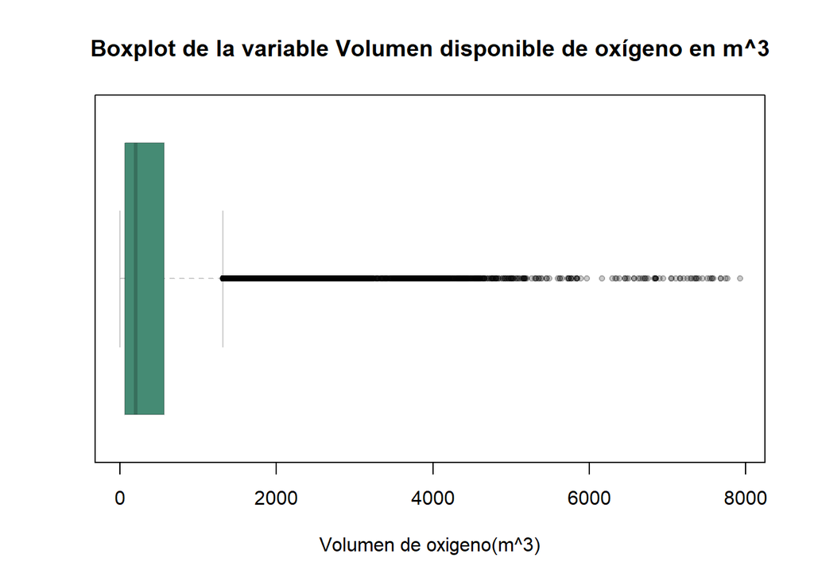

Para expresarlos usaremos el siguiente histograma:

```
##    Min. 1st Qu.  Median    Mean 3rd Qu.    Max.
##     0.0    66.0   200.0   456.3   565.0  7926.0
```

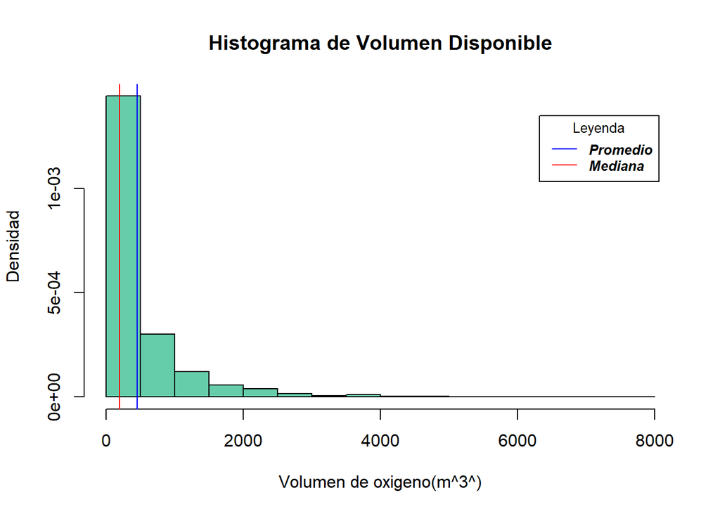

Ahora, agregamos 2 variables adicionales que relacionan los datos de nuestra base de datos, esto con el fin de determinar la **cantidad de Cilindros que sobran** y la **cantidad del volumen que no se usa por el día**, esto varía dependiendo del hospital, nuestra restricción sera que no puede haber un volumen sobrante negativo pues todo tiene que estar registrado y el sobrante expresa que no se registro bien la cantidad de cilindros o hay inconsistencia.

- **CIL_SOB_CU24: Cilindros sobrantes llenos de oxígeno por día.**

=> CIL_SOB_CU24 = CIL_NU_CIL_LLEN_INI_DU24 + CIL_NU_CIL_REABAST_DU24 - CIL_NU_CIL_CONSUM_CU24

- **VOL_OXI_DESP__CU24: Volumen de oxígeno no usado en el día.**

=> VOL_OXI_DESP__CU24 = CIL_VOL_DISP_M3_DU24 - CIL_VOL_M3_CU24

```
## [1] -146
```

|  | FECHAREGISTRO | NOMBRE | NIVEL | GRUPO | REGION | CIL_TOT_CILINDROS | CIL_VOL_POT_MT3 | CIL_NU_CIL_LLEN_INI_DU24 | CIL_NU_CIL_REABAST_DU24 | CIL_VOL_DISP_M3_DU24 | CIL_NU_CIL_CONSUM_CU24 | CIL_VOL_M3_CU24 | CIL_SOB_CU24 | VOL_OXI_DESP_CU24 |
| --- | --- | --- | --- | --- | --- | --- | --- | --- | --- | --- | --- | --- | --- | --- |
| 1 | 3/30/2021 23:14 | CLINICA Y BOTICA SAN JUAN | Nivel 2 | PRIVADOS | CAJAMARCA | 5 | 32 | 4 | 0 | 26 | 1 | 6 | 3 | 20 |
| 2 | 3/31/2021 0:40 | GRUPO CARITA FELIZ S.A. | Nivel 2 | PRIVADOS | PIURA | 30 | 300 | 30 | 0 | 300 | 5 | 50 | 25 | 250 |
| 3 | 3/31/2021 1:23 | CLINICA SANTA MARIA | Nivel 2 | PRIVADOS | LIMA | 24 | 240 | 14 | 0 | 140 | 2 | 20 | 12 | 120 |
| 4 | 3/31/2021 2:56 | HOSPITAL I HEROES DEL CENEPA | Nivel 2 | PÚBLICOS | AMAZONAS | 50 | 470 | 2 | 0 | 20 | 1 | 10 | 1 | 10 |
| 5 | 3/31/2021 5:31 | CLINICA ESPECIALIZADA EN CIRUGÍA PLÁSTICA SAN AGUSTIN | Nivel 2 | PRIVADOS | LIMA | 3 | 22 | 0 | 2 | 14 | 1 | 8 | 1 | 6 |
| 6 | 3/31/2021 5:51 | HOSPITAL II PASCO | Nivel 2 | PÚBLICOS | PASCO | 126 | 1260 | 14 | 0 | 140 | 5 | 50 | 9 | 90 |

Entonces filtramos nuestra base respecto a los valores negativos y los eliminamos porque esta información representa que no se registro los datos de manera correcta cual sea el caso.

```r
Oxigeno<-Oxigeno[Oxigeno$VOL_OXI_DESP_CU24>=0,]
head(Oxigeno)
```

|  | FECHAREGISTRO | NOMBRE | NIVEL | GRUPO | REGION | CIL_TOT_CILINDROS | CIL_VOL_POT_MT3 | CIL_NU_CIL_LLEN_INI_DU24 | CIL_NU_CIL_REABAST_DU24 | CIL_VOL_DISP_M3_DU24 | CIL_NU_CIL_CONSUM_CU24 | CIL_VOL_M3_CU24 | CIL_SOB_CU24 | VOL_OXI_DESP_CU24 |
| --- | --- | --- | --- | --- | --- | --- | --- | --- | --- | --- | --- | --- | --- | --- |
| 1 | 3/30/2021 23:14 | CLINICA Y BOTICA SAN JUAN | Nivel 2 | PRIVADOS | CAJAMARCA | 5 | 32 | 4 | 0 | 26 | 1 | 6 | 3 | 20 |
| 2 | 3/31/2021 0:40 | GRUPO CARITA FELIZ S.A. | Nivel 2 | PRIVADOS | PIURA | 30 | 300 | 30 | 0 | 300 | 5 | 50 | 25 | 250 |
| 3 | 3/31/2021 1:23 | CLINICA SANTA MARIA | Nivel 2 | PRIVADOS | LIMA | 24 | 240 | 14 | 0 | 140 | 2 | 20 | 12 | 120 |
| 4 | 3/31/2021 2:56 | HOSPITAL I HEROES DEL CENEPA | Nivel 2 | PÚBLICOS | AMAZONAS | 50 | 470 | 2 | 0 | 20 | 1 | 10 | 1 | 10 |
| 5 | 3/31/2021 5:31 | CLINICA ESPECIALIZADA EN CIRUGÍA PLÁSTICA SAN AGUSTIN | Nivel 2 | PRIVADOS | LIMA | 3 | 22 | 0 | 2 | 14 | 1 | 8 | 1 | 6 |
| 6 | 3/31/2021 5:51 | HOSPITAL II PASCO | Nivel 2 | PÚBLICOS | PASCO | 126 | 1260 | 14 | 0 | 140 | 5 | 50 | 9 | 90 |

```r
min(Oxigeno$VOL_OXI_DESP_CU24)
```

```
## [1] 0
```

Finalmente, luego de la limpieza de datos se muestran gráficas de algunas de nuestras variables:

```
##    Min. 1st Qu.  Median    Mean 3rd Qu.    Max.
##    0.00    0.00   10.00   74.82   70.00 6320.00
```

[figure not shown]

```
##    Min. 1st Qu.  Median    Mean 3rd Qu.    Max.
##    0.00    5.00   18.00   43.16   51.00  873.00
```

[figure not shown]

```
##    Min. 1st Qu.  Median    Mean 3rd Qu.    Max.
##   0.000   0.000   1.000   8.056   7.000 632.000
```

[figure not shown]

Al haberse verificado estos datos mediante Boxplot’s anteriormente (en la que se mostró que habían muchísimos “datos atípicos” por lo que ya no se les puede considerar “atípicos”), nos permite deducir que hubieron algunos centros de salud que consumieron mucha más cantidad de oxígeno debido a la gran capacidad que tienen algunos de ellos, que generalmente están ubicados en grandes ciudades. Esto porque la media y la mediana están bastante alejadas de la moda como se mostró en los gráficos, además que presentan valores máximos bastante altos en comparación con los demás datos.

La distancia entre ambos descriptores numéricos (media y mediana) se puede atribuír a la robustez de estos: la media se encuentra significativamente más alejada debido a la influencia de los datos más alejados.

### **Base de datos Camas**

```r
camas<- read_csv('CAMAS.csv')
```

Se tienen muchas variables por lo que solo filtraremos las que consideramos pertinentes para nuestro estudio, que son las que tienen que ver con las camas ocupadas, camas desocupadas, camas con cámaras de alto flujo, entre otras. Crearemos una nueva base de datos “camas”

Ahora se buscará si existen datos duplicados con la función unique()

```
## [1] "Cantidad de observaciones duplicadas: 16933"
```

Como se puede ver, hay una gran cantidad de observaciones duplicadas,es decir, hubo una deficiencia evidente en cuánto a la recolección de los datos. Por tal motivo, se omitirán estos y se trabajará con una nueva base filtrada bajo este parámetro:

```r
CamasD <- unique(Camas1)
```

Inspeccionamos la cantidad de datos faltantes y observaciones incompletas dentro de nuestra nueva base de datos.

```
## [1] "Cantidad de datos faltantes:  271978"
```

```
## [1] "Cantidad de observaciones incompletas:  46227"
```

Calcularemos el porcentaje que representan nuestros datos incompletos en la base de datos

```
## [1] "Porcentaje de datos incompletos :  13.82 %"
```

Renombramos algunas de nuestras variables para un mejor manejo de datos

Calculamos la cantidad de datos faltantes por variable para saber si hay variables con mayor cantidad de datos o si están distribuidas de manera equitativa en todas

```
##                       FECHAREGISTRO                              NOMBRE
##                                   0                                  25
##                           CATEGORIA                         INSTITUCION
##                                  25                                  25
##                               GRUPO                            SUBGRUPO
##                                  25                                  25
##                       MACROREGIONES                              REGION
##                               35217                                  25
##                           PROVINCIA                            DISTRITO
##                                  25                                  25
##                   CANULADEALTOFLUJO  PACIENTECONYSINVENTILACIONMECANICA
##                               37456                               37456
##      PACIENTECONVENTILACIONMECANICA                       CAMASOCUPADAS
##                               37456                               37456
##                    CAMASDISPONIBLES                   CAMASINOPERATIVAS
##                               37456                               37456
## CAMASOCUPADASCONVENTILACIONMECANICA CAMASOCUPADASSINVENTILACIONMECANICA
##                               37456                               37456
```

Podemos notar que que la mayor parte de NAs se encuentran en las variables cuantitativas, las cuales son las de mayor importancia para nuestro proyecto. Por lo tanto, consideramos pertinente el eliminar esas observaciones para manejar data completa y no tener resultados diferenciados por cantidad de observaciones incompletas. Construimos nuestra base de datos final

```r
CAMAS2<-na.omit(CamasD)
```

Luego especificamos el tipo de variable para no tener errores.

Quedándonos de esta forma con una nueva cantidad de observaciones

```
## [1] "Cantidad de observaciones actualizada:  54360"
```

Ahora se realizará un boxplot de la Cantidad de camas ocupadas

```
##    Min. 1st Qu.  Median    Mean 3rd Qu.    Max.
##   0.000   0.000   0.000   3.094   4.000  69.000
```

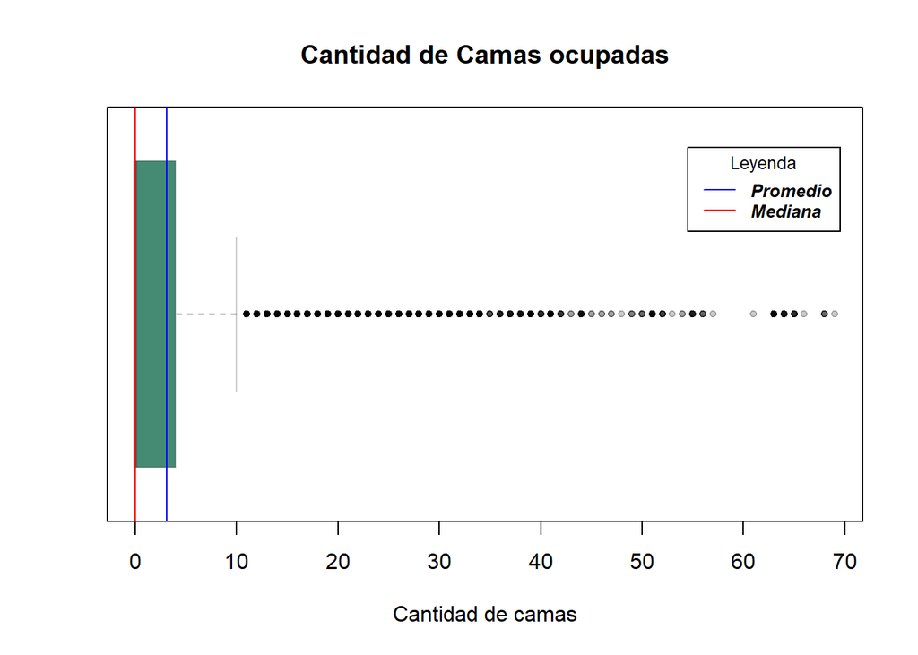

Como se puede apreciar existe una gran cantidad de Centros de Salud que no cuentan con camas UCI, ya que si no tienen ninguna cama ocupada significa que no cuentan con ello. En contraste, lo que nos muestran los datos atípicos es que hay algunos hospitales con gran cantidad de camas ocupadas (hasta 69) lo cual nos indica que al igual que ocurre con los datos de Oxigeno, hay algunos centros de salud, aunque son muy pocos, que tienen gran capacidad de atención y están bien implementados. A continuación se muestra un Histograma con la cantidad de Camas disponibles:

```
##    Min. 1st Qu.  Median    Mean 3rd Qu.    Max.
##  0.0000  0.0000  0.0000  0.8025  0.0000 28.0000
```

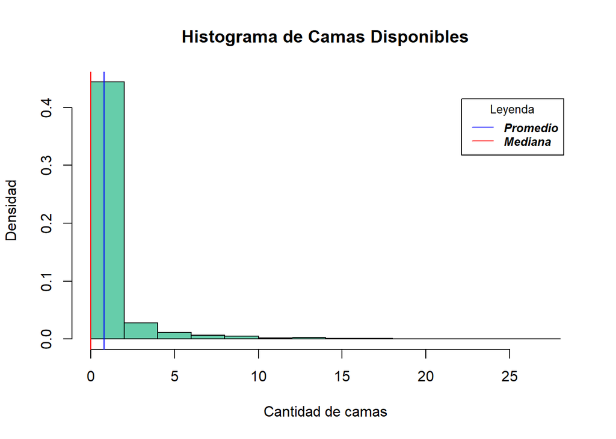

Como se puede apreciar gran cantidad de centros de salud no contaba con este requisito primordial para el tratamiento de los pacientes en estado grave de salud.

## Variables

### **Base de datos Oxígeno**

[output not shown]

### **Base de datos Camas**

[output not shown]

## Análisis descriptivo

### **Base de datos Oxígeno**

**Variable:** Nivel

Dado que es una variable categórica ordinal, nos enfocaremos en saber su frecuencia dentro de nuestra base, pues nos ayudará a determinar qué nivel de salud resalta en nuestro estudio y nos da una visualización de las IPRESS en el Perú

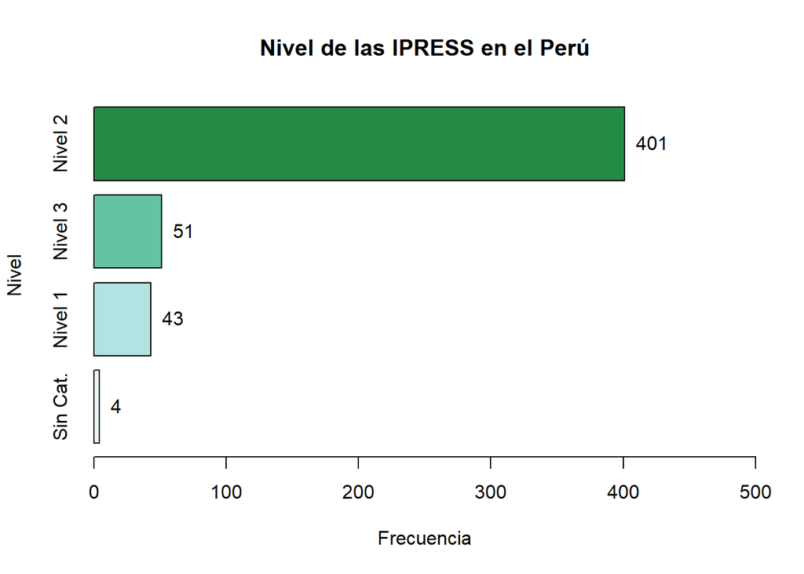

```r
HospitalL<-Oxigeno %>% select(NOMBRE,NIVEL)
HospitalL<-HospitalL[vec_unique_loc(HospitalL$NOMBRE),]
tabL<-HospitalL$NIVEL
tabL[which(HospitalL$NIVEL=="Sin Categoría")]<-"Sin Cat."
tabL<-sort(table(tabL))
HospitalLplot<-barplot(tabL,main = "Nivel de las IPRESS en el Perú",ylab="Nivel", xlab = "Frecuencia", horiz = TRUE, col=brewer.pal(n=4, name = "BuGn"), xlim = c(0,500))
text(x = tabL, y = HospitalLplot, label = data.frame(tabL)$Freq, pos = 4)
```

**Variable:**Grupo

Representa como es la distribución de las IPREES en el Perú, solo hay dos clases, privado y publico.

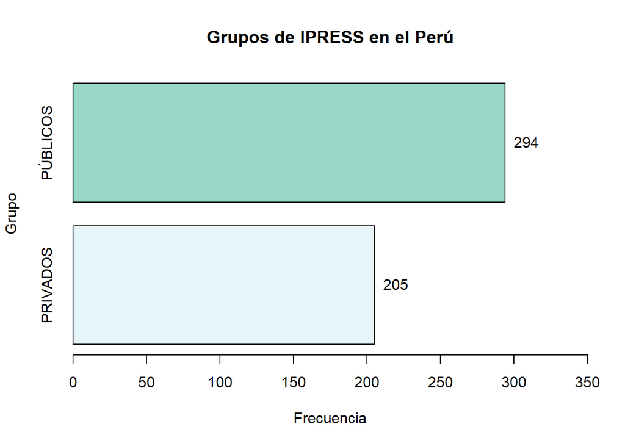

```r
HospitalG<-Oxigeno%>%select(NOMBRE,GRUPO)
HospitalG<-HospitalG[vec_unique_loc(HospitalG$NOMBRE),]
tabG<-sort(table(HospitalG$GRUPO))
HospitalGplot<-barplot(tabG,main = "Grupos de IPRESS en el Perú",ylab="Grupo", xlab = "Frecuencia", xlim=c(0, 350), horiz = TRUE, col=brewer.pal(n=3, name = "BuGn"))
text(x = tabG, y = HospitalGplot, label = data.frame(tabG)$Freq, pos = 4)
```

Se puede concluir que hay mas IPRESS de carácter publico en nuestro país

Relación: Grupos con nivel de las IPRESS

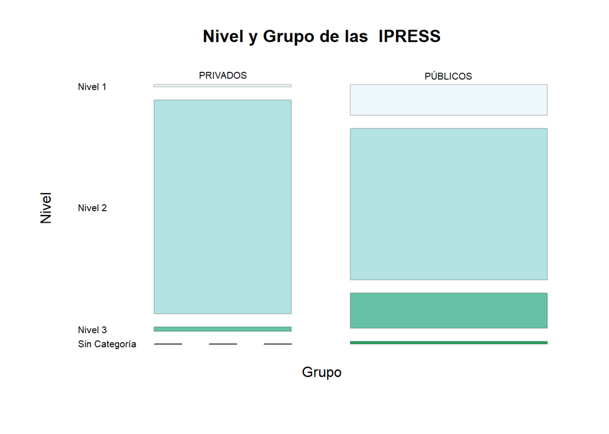

```r
mosaicplot(table(HospitalG$GRUPO,HospitalL$NIVEL),main = "Nivel y Grupo de las  IPRESS",xlab="Grupo",ylab ="Nivel",off = 15,las = 1, col=brewer.pal(n=5, name = "BuGn"),border=rgb(0,0,0,0.2))
```

El mosaico nos muestra de mejor manera la distribución de las IPRESS, concluimos que los niveles que resaltan mas son el 3 y 2, el 2 es el que resalta tanto en publicas como privadas, seguido del 3 , entendemos que las empresas privadas que brindan salud tienen que cumplir con estándares para su funcionamiento, es por ello que no encontramos sin categoría y pocos dentro del nivel 1.

**Variable:**Región Nos permite saber la distribución de las IPRESS para cada región del Perú.

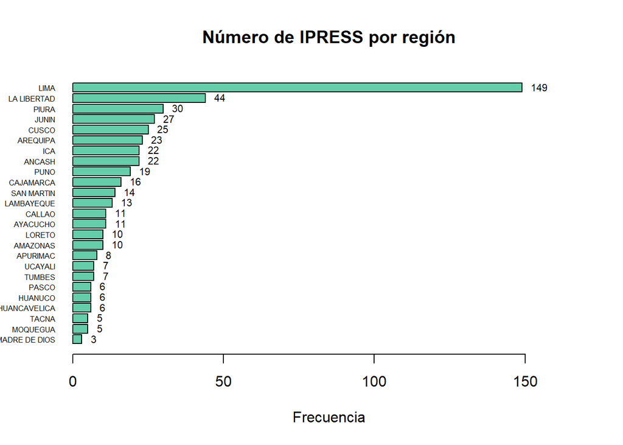

```r
HospitalR<-Oxigeno%>%select(NOMBRE,REGION)
HospitalR<-HospitalR[vec_unique_loc(HospitalR$NOMBRE),]
tabR<-sort(table(HospitalR$REGION))
HospitalRplot<-barplot(tabR,las=1,horiz = 1,main = "Número de IPRESS por región",xlab = "Frecuencia",cex.names = 0.5, xlim = c(0, 170), col=colors()[c(11)])
text(x = tabR, y = HospitalRplot, label = data.frame(tabR)$Freq, pos = 4, cex = 0.7)
```

La región de lima es la que posee mayor cantidad de IPRESS en el pais, esto tiene sentido pues Lima es la capital del pais y poseen la mayor parte de la poblacion, ademas es donde se da el mayor acceso a instrumentos de salud. Además se aprecia la centralización presente en el país, pues la diferencia entre Lima y el resto de departamentos es abismal, como se puede visualizar en la gráfica.

**Variable**:CIL_TOT_CILINDROS / Número “TOTAL” de cilindros

```r
summary(Oxigeno$CIL_TOT_CILINDROS)
```

```
##    Min. 1st Qu.  Median    Mean 3rd Qu.    Max.
##    0.00   12.00   45.00   92.06  118.00 2559.00
```

```r
mfv(Oxigeno$CIL_TOT_CILINDROS)
```

```
## [1] 10
```

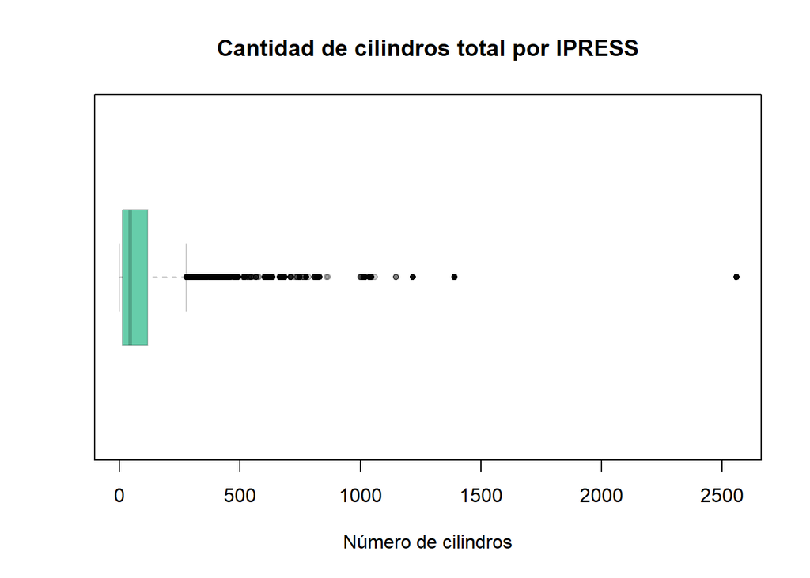

```r
boxplot(Oxigeno$CIL_TOT_CILINDROS, horizontal = 1, main =  "Cantidad de cilindros total por IPRESS",xlab="Número de cilindros",pch=20,border=rgb(0,0,0,0.2), col=colors()[c(11)])
```

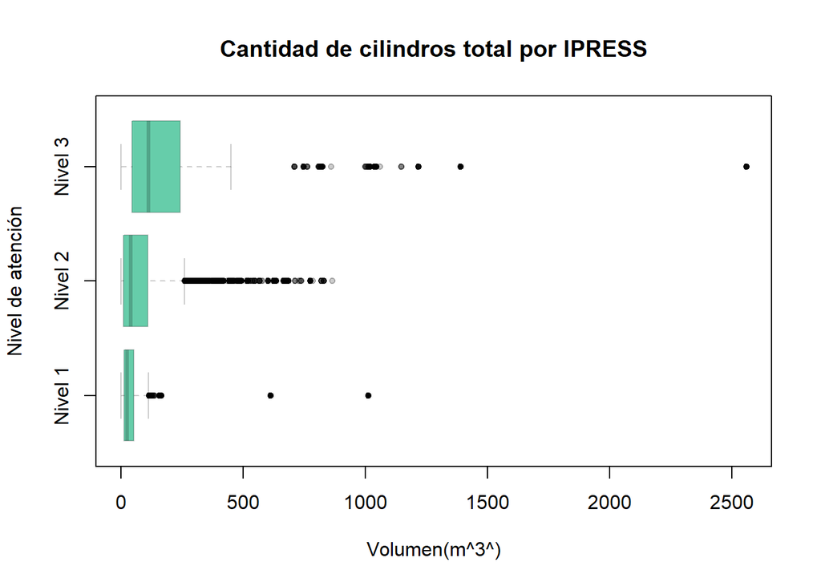

```r
boxplot(Oxigeno$CIL_TOT_CILINDROS[-which(Oxigeno$NIVEL=="Sin Categoría")] ~ Oxigeno$NIVEL[-which(Oxigeno$NIVEL=="Sin Categoría")], horizontal = 1, main =  "Cantidad de cilindros total por IPRESS",xlab="Volumen(m^3^)", ylab = "Nivel de atención" ,pch=20,border=rgb(0,0,0,0.2), col=colors()[c(11)])
```

Esto demuestra la diferencia en la calidad de recursos con la que cuentan IPRESS de cada nivel. Los diagramas de caja a continuación se presentarán también diferenciando los niveles, para comprender mejor el significado de todos aquellos valores “atípicos”. Además, se obviaron las IPRESS sin categoría, pues son muy pocas y no brindan información relevande para la investigación.

**Variable:**CIL_VOL_POT_MT3/ Volumen Potencial

```r
summary(Oxigeno$CIL_VOL_POT_MT3)
```

```
##    Min. 1st Qu.  Median    Mean 3rd Qu.    Max.
##     0.0   100.0   390.0   833.3  1072.0 12470.0
```

```r
mfv(Oxigeno$CIL_VOL_POT_MT3)
```

```
## [1] 100
```

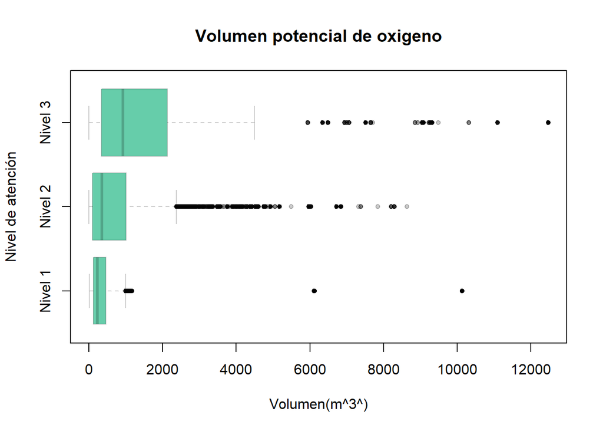

```r
boxplot(Oxigeno$CIL_VOL_POT_MT3[-which(Oxigeno$NIVEL=="Sin Categoría")] ~ Oxigeno$NIVEL[-which(Oxigeno$NIVEL=="Sin Categoría")], horizontal = 1, main =  "Volumen potencial de oxigeno",xlab="Volumen(m^3^)", ylab = "Nivel de atención" ,pch=20,border=rgb(0,0,0,0.2), col=colors()[c(11)])
```

**Variable:**CIL_NU_CIL_LLEN_INI_DU24/Número de cilindros llenos inicial por día.

```r
summary(Oxigeno$CIL_NU_CIL_LLEN_INI_DU24)
```

```
##    Min. 1st Qu.  Median    Mean 3rd Qu.    Max.
##    0.00    5.00   18.00   43.16   51.00  873.00
```

```r
mfv(Oxigeno$CIL_NU_CIL_LLEN_INI_DU24)
```

```
## [1] 1
```

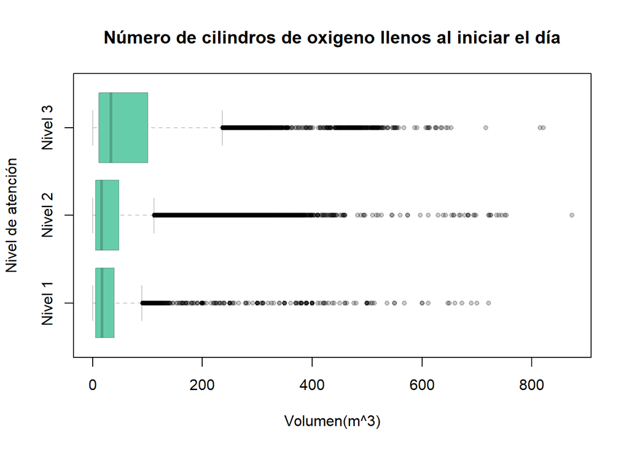

```r
boxplot(Oxigeno$CIL_NU_CIL_LLEN_INI_DU24[-which(Oxigeno$NIVEL=="Sin Categoría")] ~ Oxigeno$NIVEL[-which(Oxigeno$NIVEL=="Sin Categoría")], horizontal = 1, main =  "Número de cilindros de oxigeno llenos al iniciar el día",xlab="Volumen(m^3)", ylab = "Nivel de atención" ,pch=20,border=rgb(0,0,0,0.2), col=colors()[c(11)])
```

**Variable:**CIL_NU_CIL_CONSUM_CU24/Número de “cilindros consumidos”

```r
summary(Oxigeno$CIL_NU_CIL_CONSUM_CU24)
```

```
##    Min. 1st Qu.  Median    Mean 3rd Qu.    Max.
##   0.000   0.000   1.000   8.056   7.000 632.000
```

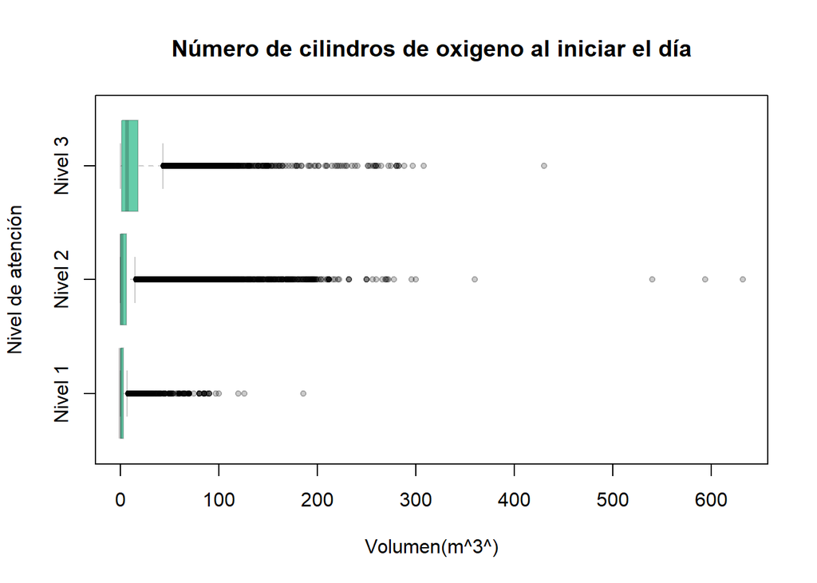

```r
boxplot(Oxigeno$CIL_NU_CIL_CONSUM_CU24[-which(Oxigeno$NIVEL=="Sin Categoría")] ~ Oxigeno$NIVEL[-which(Oxigeno$NIVEL=="Sin Categoría")], horizontal = 1, main =  "Número de cilindros de oxigeno al iniciar el día",xlab="Volumen(m^3^)", ylab = "Nivel de atención" ,pch=20,border=rgb(0,0,0,0.2), col=colors()[c(11)])
```

- **Relación entre variables:**

**Variables:**CIL_VOL_DISP_M3_DU24 y CIL_VOL_M3_CU24

Buscaremos la relación del volumen disponible por día y el volumen de oxígeno que se consumió

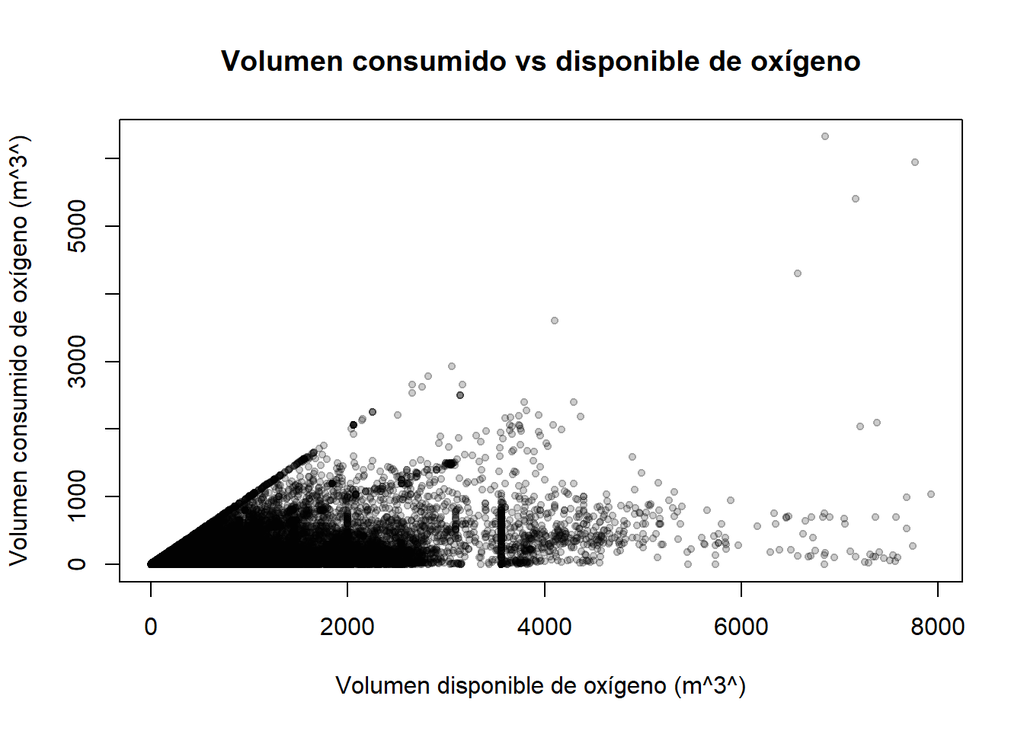

```r
plot(Oxigeno$CIL_VOL_DISP_M3_DU24,Oxigeno$CIL_VOL_M3_CU24,pch=20,col=rgb(0,0,0,0.2),xlab = "Volumen disponible de oxígeno (m^3^)", ylab = "Volumen consumido de oxígeno (m^3^)", main = "Volumen consumido vs disponible de oxígeno")
```

```r
cov(Oxigeno$CIL_VOL_DISP_M3_DU24,Oxigeno$CIL_VOL_M3_CU24)
```

```
## [1] 63804.85
```

```r
cor(Oxigeno$CIL_VOL_DISP_M3_DU24,Oxigeno$CIL_VOL_M3_CU24)
```

```
## [1] 0.5368241
```

Podemos ver que el el comportamiento de la gráfica se estanca en ciertos valores si trazamos una linea que pase por esos datos, este tendrá un comportamiento logístico, pues si bien se incrementa el volumen de oxígeno, existe un cierto limite de consumo, pues no hay mucho aforo dentro de los centros de salud y esto se relaciona con las camas UCI y equipos de ventilación mecánica, pues no podemos demandar mucho consumo aunque incremente la cantidad de volumen disponible. La covarianza nos indica la relación que hay relación entre estas dos variables, el signo positivo quiere decir que hay una relación directa. La correlación si bien es baja, es una creciente.

**Variables:**CIL_SOB_CU24 y CIL_NU_CIL_LLEN_INI_DU24:

Se buscara la relación del número de cilindros que sobran y el de disponibles por día. En esta gráfica de dispersión podemos observar una tendencia lineal positiva, la covarianza es positiva, indica la relación directa de variables, por otro lado tenemos una correlación cercano a uno, interpretándose como fuerte, entonces la relación es directamente proporcional. En cuanto a su explicación, se basa en que los cilindros que sobran aumentan la cantidad de cilindros que se tiene al iniciar un nuevo día.

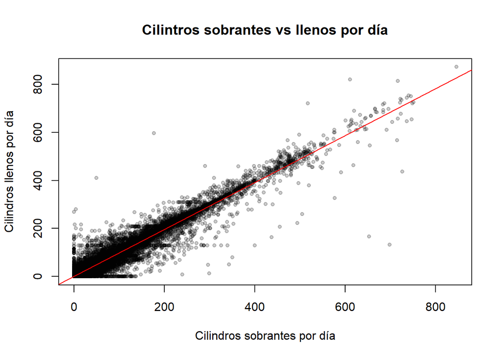

```r
plot(Oxigeno$CIL_SOB_CU24,Oxigeno$CIL_NU_CIL_LLEN_INI_DU24,pch=20,col=rgb(0,0,0,0.2),xlab = "Cilindros sobrantes por día",ylab = "Cilindros llenos por día",main = "Cilintros sobrantes vs llenos por día")
abline(lm(Oxigeno$CIL_SOB ~ Oxigeno$CIL_NU_CIL_LLEN_INI_DU24),col="red")
```

```r
cov(Oxigeno$CIL_SOB_CU24,Oxigeno$CIL_NU_CIL_LLEN_INI_DU24)
```

```
## [1] 4342.07
```

```r
cor(Oxigeno$CIL_SOB_CU24,Oxigeno$CIL_NU_CIL_LLEN_INI_DU24)
```

```
## [1] 0.978709
```

**Variables:**CIL_TOT_CILINDROS y CIL_VOL_POT_MT3

Buscamos realizar este análisis pues se buscaba observar que tan relacionados andan estas variables, si bien es lógico, hay un factor de cilindros en óptimas condiciones para su uso lo cual varia la cantidad potencial de oxígeno que una IPRESS puede tener.tenemos una relación directa entre estas variables y fuerte.

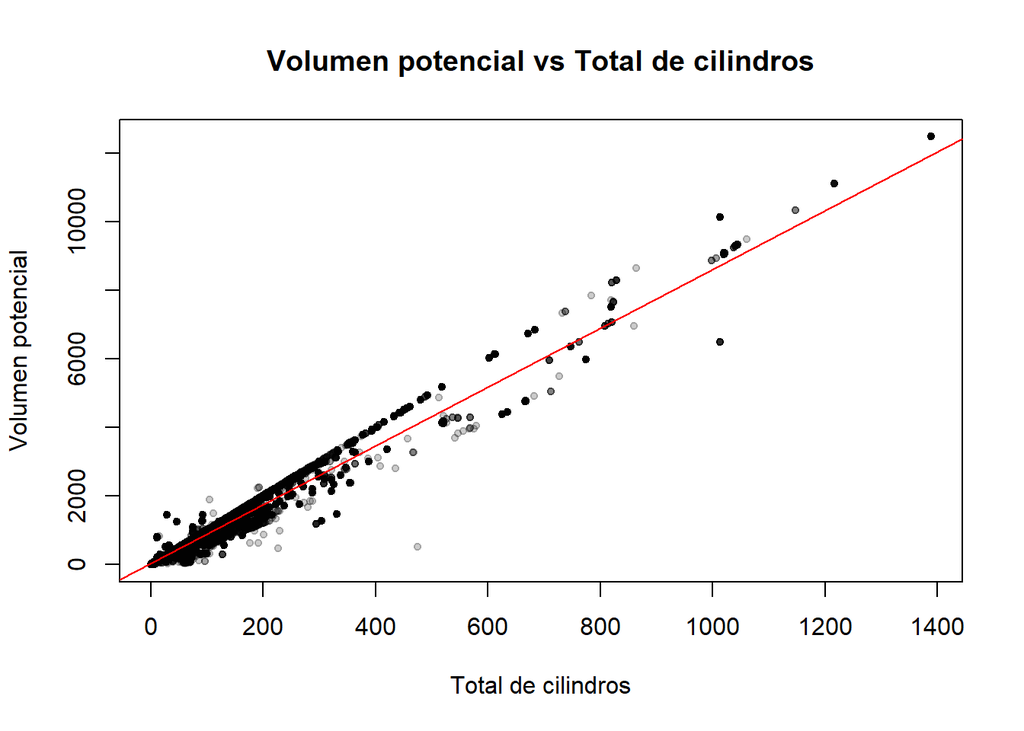

```r
plot(Oxigeno$CIL_TOT_CILINDROS[-which(Oxigeno$CIL_TOT_CILINDROS==max(Oxigeno$CIL_TOT_CILINDROS))],Oxigeno$CIL_VOL_POT_MT3[-which(Oxigeno$CIL_TOT_CILINDROS==max(Oxigeno$CIL_TOT_CILINDROS))],pch=20,col=rgb(0,0,0,0.2),xlab = "Total de cilindros",ylab = "Volumen potencial",main = "Volumen potencial vs Total de cilindros")
abline(lm(Oxigeno$CIL_VOL_POT_MT3 ~ Oxigeno$CIL_TOT_CILINDROS),col="red")
```

```r
cov(Oxigeno$CIL_TOT_CILINDROS,Oxigeno$CIL_VOL_POT_MT3)
```

```
## [1] 175726.6
```

```r
cor(Oxigeno$CIL_TOT_CILINDROS,Oxigeno$CIL_VOL_POT_MT3)
```

```
## [1] 0.9574808
```

### **Base de datos Camas**

- **Análisis descriptivo**

**Variable:*Categoría

Esta variable de clasificación que caracteriza a los IPRESS, en base a niveles de complejidad y a características funcionales comunes, que determina su capacidad resolutiva, respondiendo a realidades socio sanitarias similares y diseñadas para enfrentar demandas equivalentes.

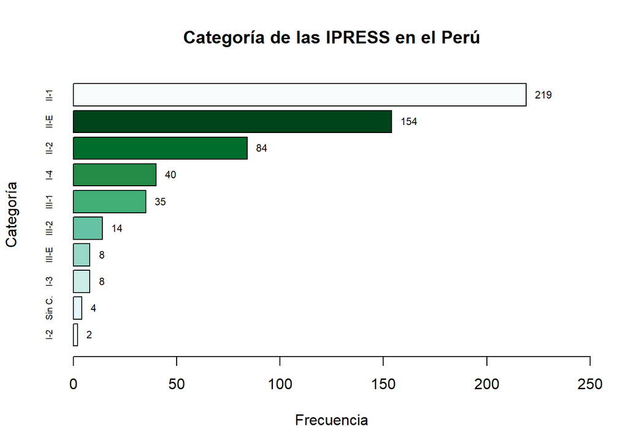

```r
HOSP2<-Camas1 %>% select(NOMBRE,CATEGORIA)
HOSP2<-HOSP2[vec_unique_loc(HOSP2$NOMBRE),]
h2<-HOSP2$CATEGORIA
h2[which(HOSP2$CATEGORIA=="Sin Categoría")]<-"Sin C."
tab2<-sort(table(h2))
HOSP2plot<-barplot(tab2,main = "Categoría de las IPRESS en el Perú",ylab="Categoría", xlab = "Frecuencia", horiz = TRUE, xlim = c(0, 250), cex.names=0.6, col=brewer.pal(n=9, name = "BuGn"))
text(x = tab2, y = HOSP2plot, label = data.frame(tab2)$Freq, pos = 4, cex = 0.7)
```

Esta gráfica nos ayuda a determinar la categoría de las IPREES a nivel nacional, podemos ver que resalta la categoría II-1 correspondiente a hospitales y clínicas de atención general, donde se tiene como funciones principales: la promoción, prevención, recuperación, rehabilitación y gestión general. Exiten una gran similitud en cuanto a las categorías I-4 y III-1, sin embargo se diferencian la correspondencia y actividades que se realizan, siendo I-4, correspondiente a centros de salud de camas de internamiento y III-1 a hospitales y clínicas de atención general. En conclusión, en nuestro pais cuenta con una categoría intermedia con establecimientos de atención general.

**Variable:**Grupo Representa como es la distribución de las IPREES en el Perú, solo hay dos clases, privado y publico.

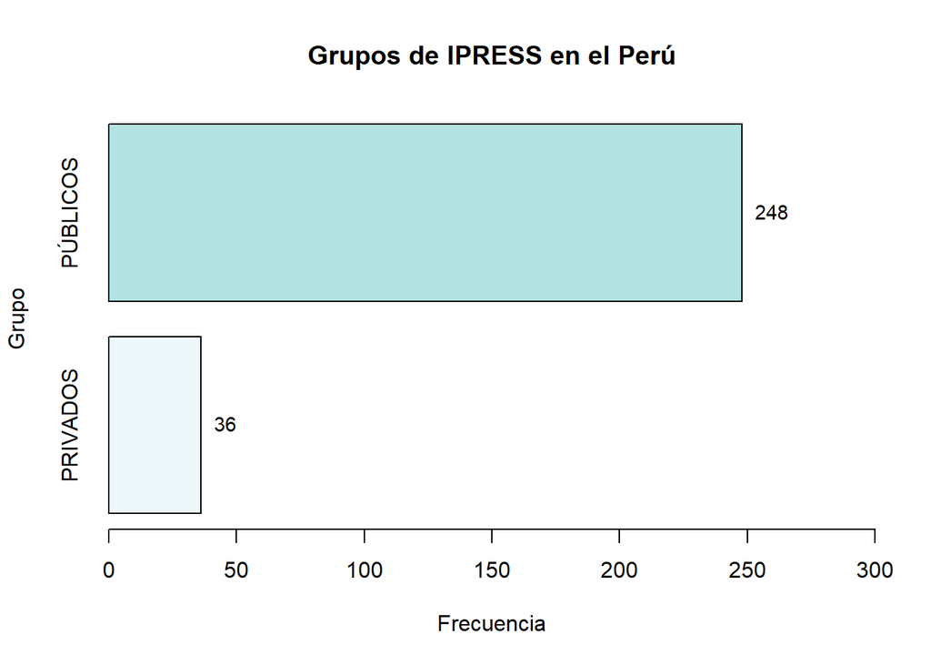

```r
GRUPO1<-CAMAS2%>%select(NOMBRE,GRUPO)
GRUPO1<-GRUPO1[vec_unique_loc(GRUPO1$NOMBRE),]
tab1<-sort(table(GRUPO1$GRUPO))
GRUPO1plot<-barplot(tab1,main = "Grupos de IPRESS en el Perú",ylab="Grupo", xlab = "Frecuencia", xlim=c(0, 300), horiz = TRUE, col=brewer.pal(n=4, name = "BuGn"))
text(x = tab1, y = GRUPO1plot, label = data.frame(tab1)$Freq, pos = 4, cex = 0.9)
```

Esta gráfica nos indica que existen muchos más IPRESS , que pertencen en al sector público.

**Relación** Grupos con categoría de las IPRESS

**Variable:**Región Nos permite saber la distribución de las IPRESS para cada región del Perú.

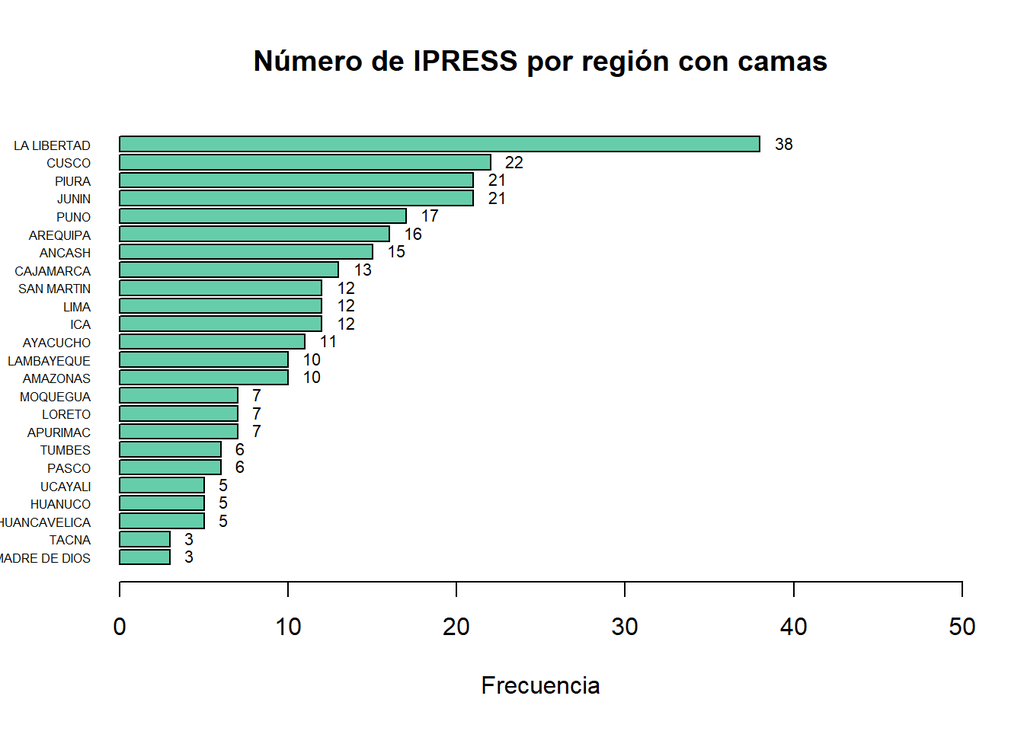

```r
HOSP2<-CAMAS2%>%select(NOMBRE,REGION,CATEGORIA)
HOSP2<-HOSP2[vec_unique_loc(HOSP2$NOMBRE),]
tabb2<-sort(table(HOSP2$REGION))
HOSP2plott<-barplot(tabb2,las=1,horiz = 1,main = "Número de IPRESS por región con camas",xlab = "Frecuencia",cex.names = 0.5, xlim = c(0, 50), col=colors()[c(11)])
text(x = tabb2, y = HOSP2plott, label = data.frame(tabb2)$Freq, pos = 4, cex = 0.7)
```

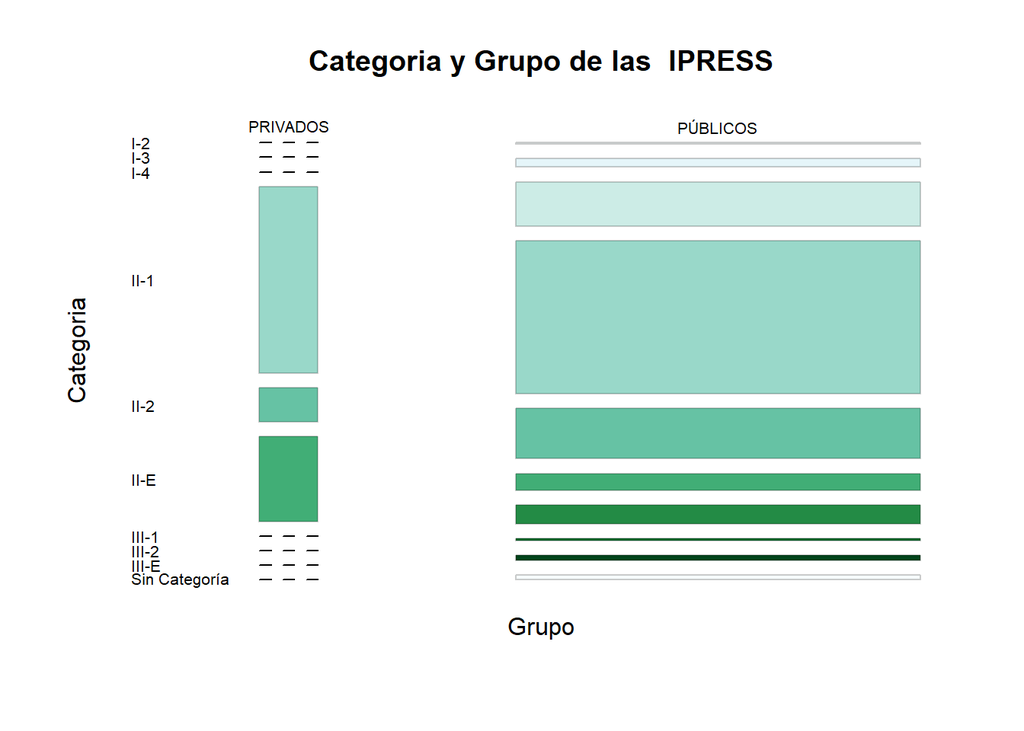

```r
mosaicplot(table(GRUPO1$GRUPO,HOSP2$CATEGORIA),main = "Categoria y Grupo de las  IPRESS",xlab="Grupo",ylab ="Categoria",off = 30,las = 1, col=brewer.pal(n=9, name = "BuGn"),border=rgb(0,0,0,0.2))
```